# Chapter07. 가중최소제곱

Jeong-Eun Lee

2021 7 13

### 7.1 소개

- 이분산성 : 오차들이 같은 분산을 갖지 못하는 것
- 자기상관 : 오차들이 독립이 아닌 것
- 가중최소제곱법(WLS) : 변환된 변수들에 대해 최소제곱추정법(OLS)를 수행하는 것
  - 이 장에서 다루는 WLS는 이분산성을 갖는 오차를 다루는 방법과 그 추정 방법에 관한 것이다.
  - WLS는 함량-반응곡선과 로지스틱 모형에 대한 적합에서 OLS보다 우수함
- WLS추정은 다음의 식을 최소화함으로써 얻어짐
  $$\sum_{i = 1}^{n} w_i(y_i - \beta_0 - \beta_1x_{i1} - ... - \beta_px_{ip})^2$$
  - $w_i$ : 분산에 반비례하는 가중치 -> $w_i = 1/\sigma_i^2$
- WLS 방법의 특징
  - 작은 가중치를 가지는 관찰값은 회귀계수 $\beta_0, \beta_1, ..., \beta_p$의 값을 결정하는 데 적은 영향을 미침
  - 극단적인 경우 $w_i = 0$이면 $i$번째 관측개체는 추정과정에서 제외되는 효과를 가짐
- 가중치 $w_i$가 알려져있지 않다면
  - 단계 1) OLS에 의한 결과로부터 가중치를 추정
  - 단계 2) 단계 1에서 구한 가중치를 기초로 WLS를 적용하여 추정치를 구함함

### 7.2 이분산성 모형 & 7.3 이단계 추정

- 이분산성의 문제가 제기될 수 있는 상황
  1. 오차항 $\epsilon_i$의 분산이 설명변수($x_i$)에 의존하는 경우 -> WLS법 사용하여 해결
     - $Var(\epsilon_i) = k^2x_{i2}^2$일 때, $\sum_{i = 1}^{n} 1/x_{i2}^2 (y_i - \beta_0 - \beta_1x_{i1}-...-\beta_px_{ip})^2$를 최소화하여 회귀계수의 추정치를 구함
  2. 잘 정의된 그룹이나 군집으로부터 얻어진 개별 추출단위들의 평균을 관측치로 다루는 대규모 표본조사의 경우 -> WLS법 사용하여 해결
     - $\sigma_i^2 = \sigma^2/n_i$일 때, $S = \sum_{i = 1}^{n} n_i(y_i - \beta_0 - \sum_{j = 1}^{6} \beta_jx_{ij})^2$를 최소화하여 회귀계수의 추정치를 구함
  3. 분산이 동일하지 않다는 사전의 예상이 가능하나, 이분산성의 구체적인 구조는 표본을 얻은 후에 경험적으로 결정되는 경우 -> 이단계(two stage) 추정 절차

### 7.4 교육비 지출 데이터

- 데이터는 1975년 부분만을 사용함
- 가정 : 각 지리별 영역별로 전체적인 회귀관계의 구조는 같으나, 잔차분산과 회귀계수는 서로 다를 가능성이 있음 -> 이분산성의 문제 고려
- 모형(식 7.8) : $Y = \beta_0 + \beta_1X_1 + \beta_2X_2 + \beta_3X_3 + \epsilon$
- 그룹화 : (1) 북동 (2) 북부중앙 (3) 남부 (4) 서부
  - 50개 주는 지리적 동질성이 존재한다는 가정에 기반하여 지역별 차이에 관한 정보를 가중최소제곱법에 확장함
  - 4개의 지역별로 서로 다른 오차분산이 존재한다고 가정 : $(c_1\sigma)^2, (c_2\sigma)^2, (c_3\sigma)^2, (c_4\sigma)^2$
    - (WLS) $S_w = S_1 + S_2 + S_3 + S_4$를 최소화하여 모회귀계수의 최소제곱추정량을 구함
    - 여기서 $S_j = \sum_{i = 1}^{n_j} 1/c_j^2 (y_i - \beta_0 - \beta_1x_{i1} - \beta_2x_{i2} - \beta_3x_{i3})^2, j = 1, 2, 3, 4$ … (식 7.9)
      - $c_j^2$는 가중치 : 오차가 큰 관측값이 회귀계수의 결정에 작은 영향을 끼치게 하는 효과를 가짐 -> 다중선형회귀와의 차이점
      - $c_j^2$는 미지의 값 -> 데이터로부터 추정 -> 이단계 추정법
- 이단계 추정법
  - 단계 1) 원래 데이터에 (식 7.8) 모형을 사용한 회귀분석을 수행 + 지역별로 얻은 경험적 잔차로부터 지역별 오차분산의 추정값을 계산
    - ex) 북동지역(1)의 경우, $\hat{\sigma_1} = \sum e_i^2/(9-1)$
  - 단계 2) (식 7.9)의 $c_j^2$의 추정치는 $\hat{c_j^2} = \hat{\sigma_j^2} / n^{-1} \sum_{i = 1}^{n} e_i^2$로 대체됨

```r
edu = read.table("C:\\Users\\X-Note\\Desktop\\edu.txt", header = T)
head(edu)
```

```
##   State   Y   X1  X2  X3 Region
## 1    ME 235 3944 325 508      1
## 2    NH 231 4578 323 564      1
## 3    VT 270 4011 328 322      1
## 4    MA 261 5233 305 846      1
## 5    RI 300 4780 303 871      1
## 6    CT 317 5889 307 774      1
```

```r
lm_edu = lm(Y ~ X1 + X2 + X3, data = edu)
summary(lm_edu)
```

```
##
## Call:
## lm(formula = Y ~ X1 + X2 + X3, data = edu)
##
## Residuals:
##     Min      1Q  Median      3Q     Max
## -84.878 -26.878  -3.827  22.246  99.243
##
## Coefficients:
##               Estimate Std. Error t value Pr(>|t|)
## (Intercept) -5.566e+02  1.232e+02  -4.518 4.34e-05 ***
## X1           7.239e-02  1.160e-02   6.239 1.27e-07 ***
## X2           1.552e+00  3.147e-01   4.932 1.10e-05 ***
## X3          -4.269e-03  5.139e-02  -0.083    0.934
## ---
## Signif. codes:  0 '***' 0.001 '**' 0.01 '*' 0.05 '.' 0.1 ' ' 1
##
## Residual standard error: 40.47 on 46 degrees of freedom
## Multiple R-squared:  0.5913, Adjusted R-squared:  0.5647
## F-statistic: 22.19 on 3 and 46 DF,  p-value: 4.945e-09
```

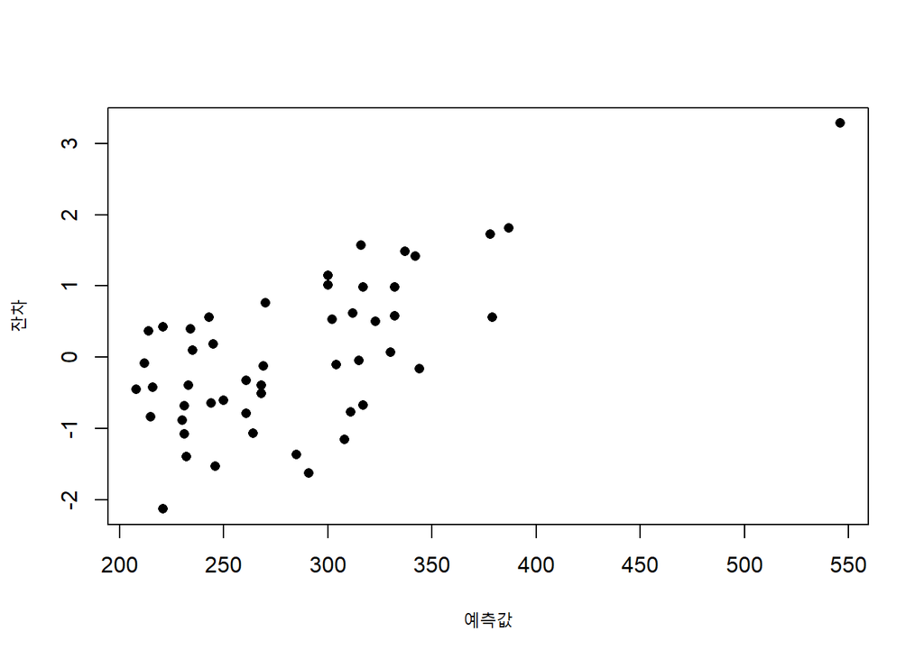

```r
plot(edu$Y, rstandard(lm_edu), xlab = "예측값", ylab = "잔차", pch = 16)
```

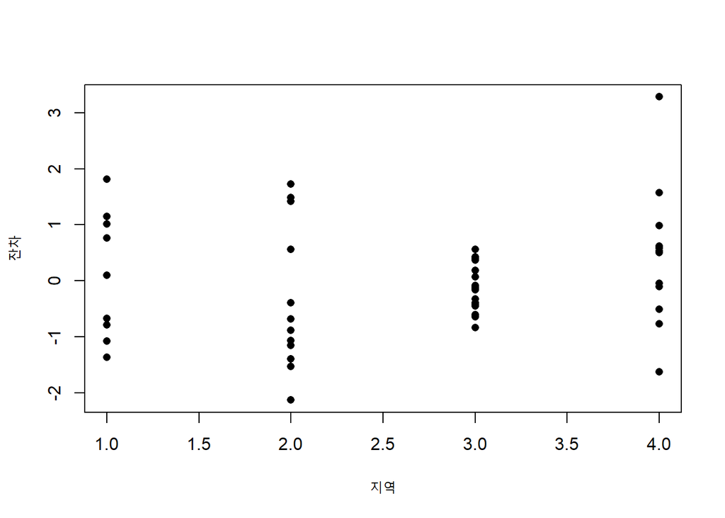

```r
plot(edu$Region, rstandard(lm_edu), xlab = "지역", ylab = "잔차", pch = 16)
```

- 표준화잔차 대 지역의 플롯 - 지역별로 잔차의 흐트러진 정도가 서로 다름 -> 분산이 지역별로 다름

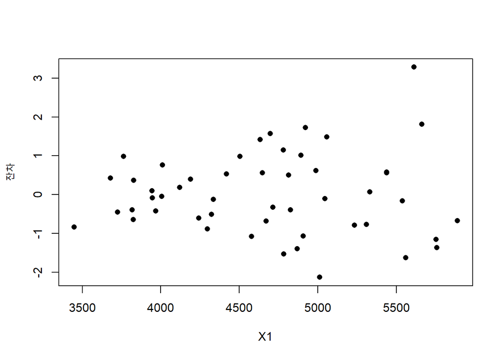

```r
plot(edu$X1, rstandard(lm_edu), xlab = "X1", ylab = "잔차", pch = 16)
```

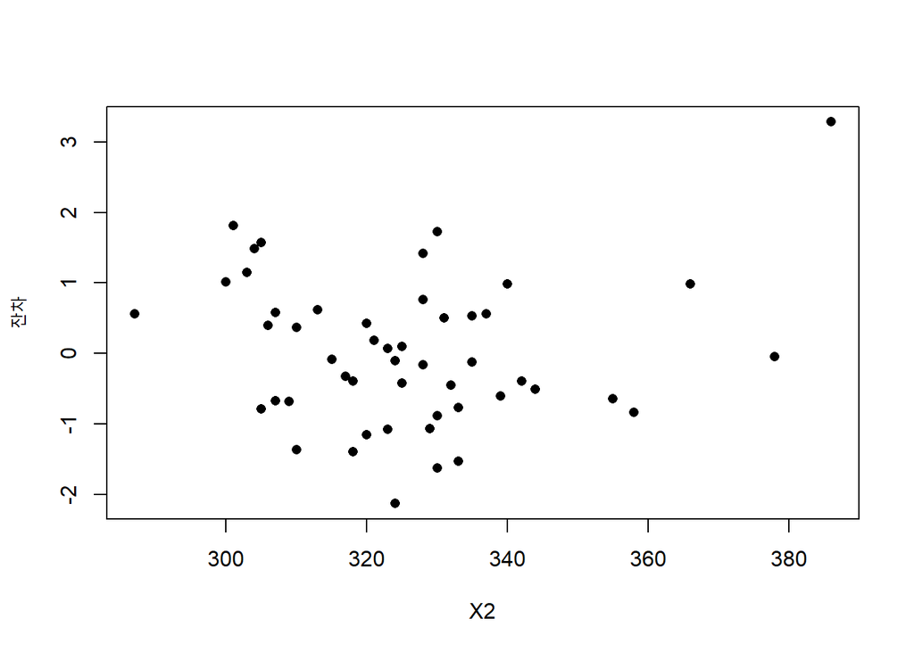

```r
plot(edu$X2, rstandard(lm_edu), xlab = "X2", ylab = "잔차", pch = 16)
```

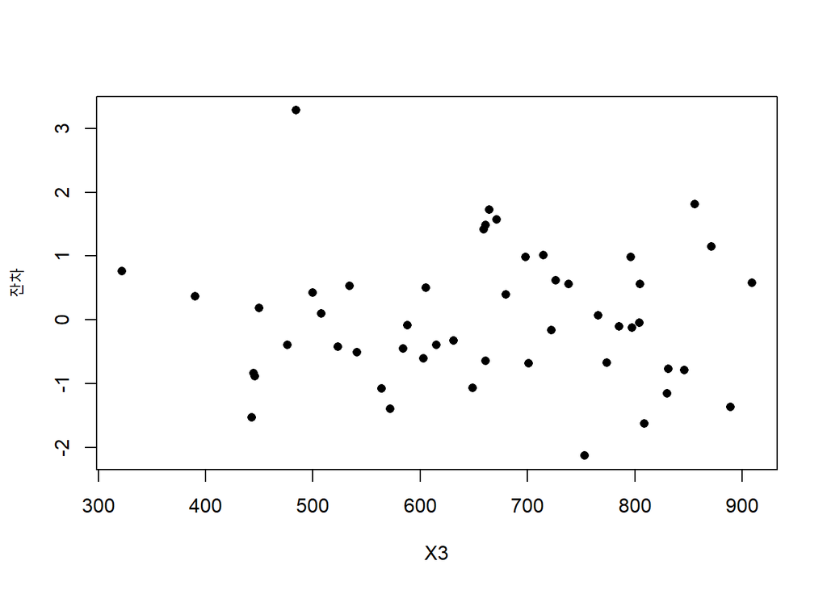

```r
plot(edu$X3, rstandard(lm_edu), xlab = "X3", ylab = "잔차", pch = 16)
```

- 표준화잔차와 각 예측변수에 대한 산점도 - 변수 $X_1$에 대해 잔차의 분산이 증가하고 있음

```r
lm_edu2 = lm(Y[-49] ~ X1[-49] + X2[-49] + X3[-49], data = edu)
summary(lm_edu2)
```

```
##
## Call:
## lm(formula = Y[-49] ~ X1[-49] + X2[-49] + X3[-49], data = edu)
##
## Residuals:
##     Min      1Q  Median      3Q     Max
## -81.128 -22.154  -7.542  22.542  80.890
##
## Coefficients:
##               Estimate Std. Error t value Pr(>|t|)
## (Intercept) -277.57731  132.42286  -2.096 0.041724 *
## X1[-49]        0.04829    0.01215   3.976 0.000252 ***
## X2[-49]        0.88693    0.33114   2.678 0.010291 *
## X3[-49]        0.06679    0.04934   1.354 0.182591
## ---
## Signif. codes:  0 '***' 0.001 '**' 0.01 '*' 0.05 '.' 0.1 ' ' 1
##
## Residual standard error: 35.81 on 45 degrees of freedom
## Multiple R-squared:  0.4967, Adjusted R-squared:  0.4631
## F-statistic:  14.8 on 3 and 45 DF,  p-value: 7.653e-07
```

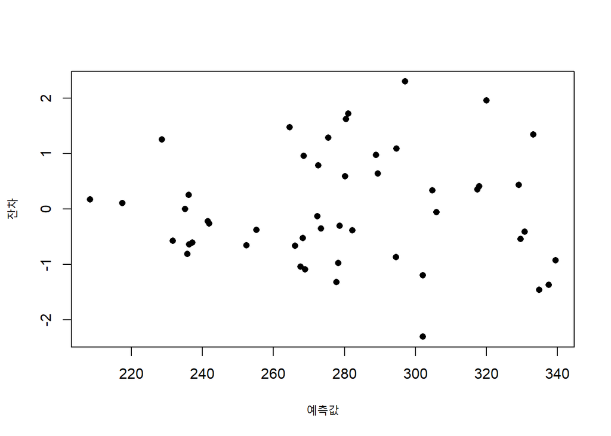

```r
plot(lm_edu2$fitted.values, rstandard(lm_edu2), xlab = "예측값", ylab = "잔차", pch = 16)
```

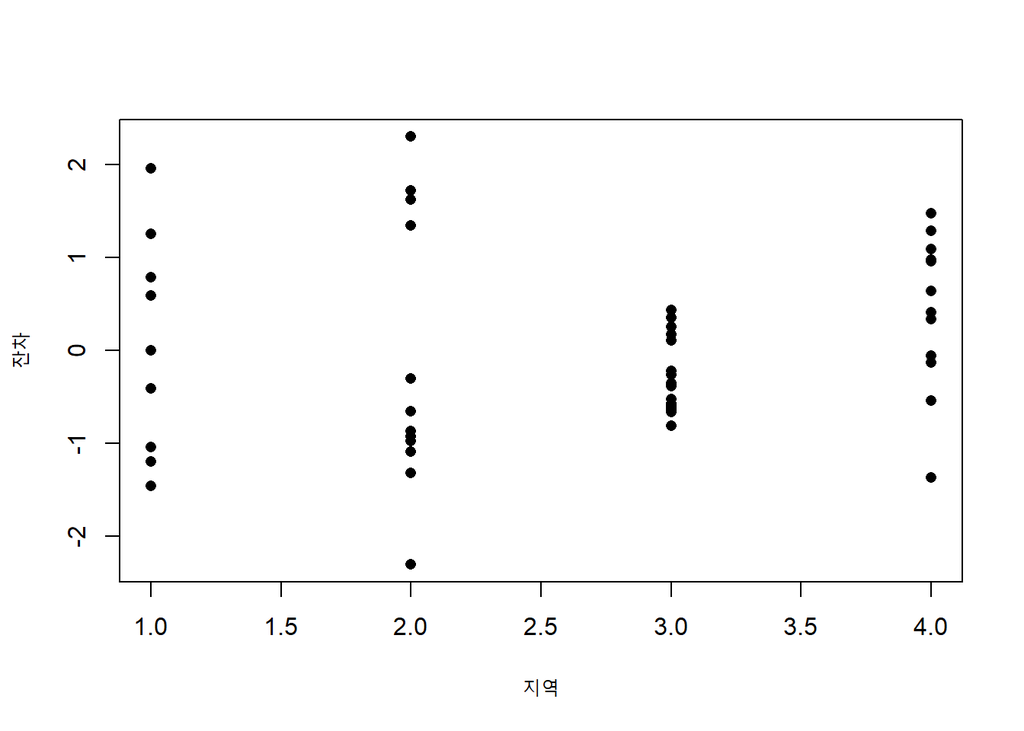

```r
plot(edu$Region[-49], rstandard(lm_edu2), xlab = "지역", ylab = "잔차", pch = 16)
```

- 49번 개체를 제거한 후의 교육비 지출 데이터에 대한 회귀분석 결과와 표준화잔차 대 적합값의 플롯, 표준화잔차 대 지역의 플롯 이다. 이 그림들을 보면 여전히 이분산성이 나타나고 있음을 알 수 있다.

### WLS 계산

- 이 모형에 대해 WLS 추정을 하기 위해 $c_j$를 먼저 추정해야 한다.
  $$\hat{c}_j^{2} = \frac{\hat{\sigma}_j^2}{\frac{1}{n}\sum_{i=1}^{n}e_i^2}$$
  이때 $\hat{\sigma}_1^2 = \sum e_i^2/(9-1)$ 등으로 구한다.

```r
sigma_hat_1 <- sum(lm_edu2$residuals[which(edu$Region==1)]^2)/(sum(edu$Region==1)-1)
sigma_hat_2 <- sum(lm_edu2$residuals[which(edu$Region==2)]^2)/(sum(edu$Region==2)-1)
sigma_hat_3 <- sum(lm_edu2$residuals[which(edu$Region==3)]^2)/(sum(edu$Region==3)-1)
sigma_hat_4 <- sum(lm_edu2$residuals[-which(edu$Region%in%c(1,2,3))]^2)/(sum(edu$Region==4)-2) #알래스카 제거 때문
sigma_hat_tot <- sum(lm_edu2$residuals^2)/(length(lm_edu2$residuals))

c_hat_1 <- sqrt(sigma_hat_1/sigma_hat_tot)
c_hat_2 <- sqrt(sigma_hat_2/sigma_hat_tot)
c_hat_3 <- sqrt(sigma_hat_3/sigma_hat_tot)
c_hat_4 <- sqrt(sigma_hat_4/sigma_hat_tot)

edu3 <- edu[-49,]
lm_edu3 = lm(Y ~ X1 + X2 + X3, data = edu3, weights = c(rep(1/c_hat_1^2, 9), rep(1/c_hat_2^2, 12), rep(1/c_hat_3^2, 16), rep(1/c_hat_4^2, 12)))
summary(lm_edu3)
```

```
##
## Call:
## lm(formula = Y ~ X1 + X2 + X3, data = edu3, weights = c(rep(1/c_hat_1^2,
##     9), rep(1/c_hat_2^2, 12), rep(1/c_hat_3^2, 16), rep(1/c_hat_4^2,
##     12)))
##
## Weighted Residuals:
##     Min      1Q  Median      3Q     Max
## -55.498 -23.383  -2.447  26.233  61.651
##
## Coefficients:
##               Estimate Std. Error t value Pr(>|t|)
## (Intercept) -3.160e+02  7.742e+01  -4.082 0.000181 ***
## X1           6.246e-02  7.803e-03   8.005 3.39e-10 ***
## X2           8.740e-01  1.984e-01   4.405 6.46e-05 ***
## X3           2.892e-02  3.399e-02   0.851 0.399351
## ---
## Signif. codes:  0 '***' 0.001 '**' 0.01 '*' 0.05 '.' 0.1 ' ' 1
##
## Residual standard error: 32.33 on 45 degrees of freedom
## Multiple R-squared:  0.7605, Adjusted R-squared:  0.7445
## F-statistic: 47.62 on 3 and 45 DF,  p-value: 5.189e-14
```

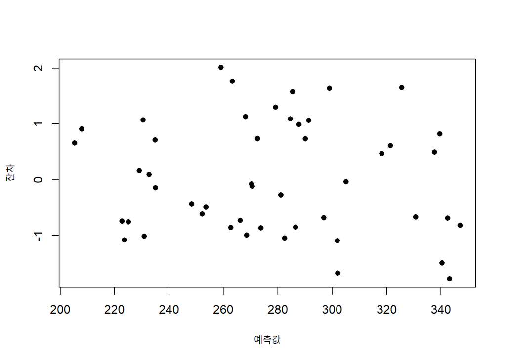

```r
plot(lm_edu3$fitted.values, rstandard(lm_edu3), xlab = "예측값", ylab = "잔차", pch = 16)
```

- [그림 7.10] : WLS 해에 대한 표준화잔차 대 적합값의 플롯 - 특별한 패턴 x

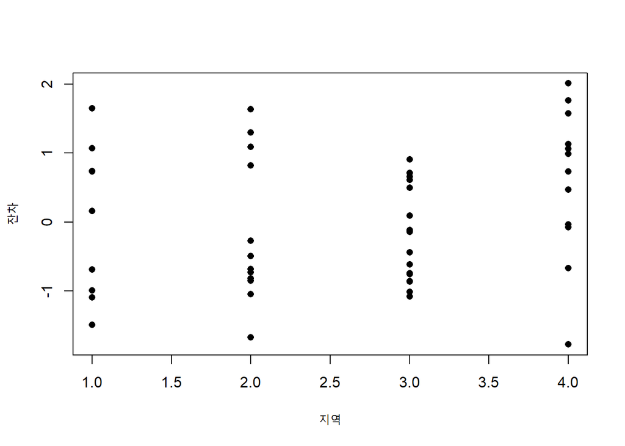

```r
plot(edu3$Region, rstandard(lm_edu3), xlab = "지역", ylab = "잔차", pch = 16)
```

### 7.5 함량 - 반응 연관곡선의 적합

- 로지스틱 반응함수 : $\pi_j = e^{\beta_0 + \beta_1x_j} / 1 + e^{\beta_0 + \beta_1x_j}$ ; 0과 1 사이의 값을 갖는 단조증가함수
- 로지스틱 모형
  - 의학, 약학, 리스크분석, 학습이론, 소비자행동 이론 등에 널리 사용
  - 이항반응에 관한 데이터에서 반응비율에 대한 분석이 매우 타당하고 적합하기 쉬운 방법
- 프로빗 모형 : 로지스틱 반응함수 대신 누적정규분포함수를 반응함수로 하는 것에 기초한 분석